# Ensemble_Methods_for_Outlier_Detection_Version_2.0

Jian Song, Nathan P. Manes

5/5/2022

## 1. Set the Statistical Parameters and Prepare and Visualize the Input Data

The four statistical cutoff values are set below. Your input file is loaded in here. The data are filtered by removing any row with “NaN” (missing values). Density plots are used to visualize the distribution of gene/protein expression values within each sample and across the samples. The normality of the dataset is visualized and tested. Note that it is unclear how accurately outliers will be detected if the input dataset is significantly different from a normal distribution.

```r
# Set the Cophenetic Correlation Coefficient (CCC) cutoff (higher is more stringent).
# The CCC is a measure of how faithfully a dendrogram preserves the pairwise distances
# between the original unmodeled data points.
CCC_min <- 0.8

# Set the Silhouette Coefficient (SC) cutoff (lower is more stringent).
# The SC is a measure of how similar an object is to its own cluster (cohesion) compared to other clusters (separation).
SC_max <- 0.25

# Set the Robust PCA algorithm (robpca) cutoff (higher is more stringent).
# For normally distributed data, this value is the estimated fraction of the samples that are not falsely classified as outliers.
robpca_prob <- 0.975

# Set the Robust PCA algorithm (PcaGrid) cutoff (higher is more stringent)
# For normally distributed data, this value is the estimated fraction of the samples that are not falsely classified as outliers.
PcaGrid_prob <- 0.975


# To analyze your table of data, paste it in a new Excel file named "Gene_Expression_Table.xlsx".
# Rows = genes/proteins.  Columns = samples.  Values = expression values.
# The first row is for the column headers (sample identifiers).
# Don't have gene/protein identifiers in the first column; use all columns for abundance values.
# Place this file in the same directory as this R script.
# Optional: if present, remove any extra header rows using e.g. "skip=19" - which will remove the 19 header rows
input_data <- readxl::read_xlsx("./Gene_Expression_Table.xlsx", skip = 0, col_names = TRUE, col_types=NULL)
input_data <- data.frame(input_data)
rownames(input_data) <- input_data$Leading.Protein.ID
input_data$Leading.Protein.ID <- NULL # Remove the gene/protein ID column if present
input_data <- as.data.frame(sapply(input_data, as.numeric))

# Display the first six rows of the input data
head(input_data)
```

```
##   ID_04_Female_EoE ID_07_Female_EoE ID_10_Female_EoE ID_12_Female_EoE
## 1         8.050033         7.638530         7.744855         7.919658
## 2         8.715685         8.332488         8.438568         8.835373
## 3         7.691108              NaN              NaN              NaN
## 4         7.199514         7.587560         7.493022              NaN
## 5         7.354082         7.492012         7.431591         7.479611
## 6         6.741754         7.001199              NaN         6.800125
##   ID_biopsy_4_Female_EoE ID_01_Male_EoE ID_06_Male_EoE ID_11_Male_EoE
## 1               7.874698       7.910957       7.990388       7.892744
## 2               8.724307       8.735410       8.950138       8.915653
## 3                    NaN       7.196826            NaN            NaN
## 4                    NaN       7.348529       7.278650            NaN
## 5               7.526987       7.457198       7.599581       7.552894
## 6               6.658362       7.004727       7.116361       6.858771
##   ID_13_Male_EoE ID_biopsy_2_Male_EoE ID_03_Female_NL ID_14_Female_NL
```

[output cut: 20 more lines]

```r
# Display the dimension of the input table
# Number of rows (genes/proteins) and the number of columns (samples)
dim(input_data)
```

```
## [1] 3341   20
```

```r
# Remove any row (genes/proteins) with one or more invalid values ("NaN")
input_data_nna <- input_data[complete.cases(input_data), ]
# Display how many rows remain after removing the rows with NaN's
input_data_nna_rows <- dim(input_data_nna)[1]
input_data_col <- dim(input_data_nna)[2]
dim(input_data_nna)
```

```
## [1] 1443   20
```

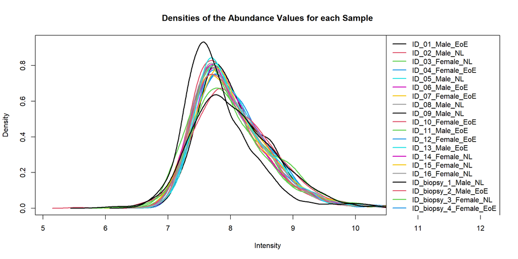

```r
# Plot the density of expression values for all of the samples on the same plot.
# If the samples are very diverse, a global normalization might be helpful.
# Note that this is not a visualization of how close the quantification is to a normal distribution.
plotDensities(input_data_nna, log = FALSE, main="Densities of the Abundance Values for each Sample", legend = "topright")
```

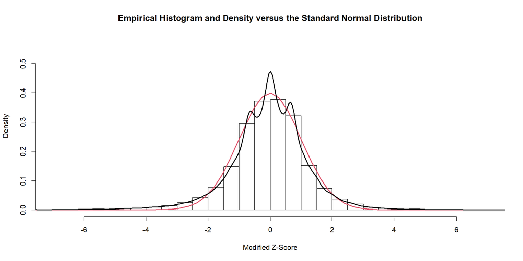

```r
# We cannot label each line in the plot above, but we can plot a subset of
# the samples to be able to differentiate the lines.
# For example, to plot the distributions of 'Sample_01', 'Sample_02', and 'Sample_03', use
# plotDensities(input_data_nna[c('Sample_01', 'Sample_02', 'Sample_03')], log = FALSE, main="Densities of the Abundance Values for Selected Samples", legend = "topright")
#
# The expression values should have a normal distribution.  To check this,
# the data are scaled by calculating the Modified Z-score (Iglewicz and Hoaglin 1993)
# within each row across the samples.

input_data_nna_median <- vector("numeric", input_data_nna_rows)
for (i in 1:input_data_nna_rows) {
input_data_nna_median[i] <- median(unlist(input_data_nna[i,]))
}

input_data_nna_MAD <- vector("numeric", input_data_nna_rows)
for (i in 1:input_data_nna_rows) {
input_data_nna_MAD[i] <- mad(unlist(input_data_nna[i,]), center = input_data_nna_median[i], constant = 1, na.rm = TRUE, low = FALSE, high = FALSE)
}

input_data_nna_ModZ <- matrix(nrow = input_data_nna_rows, ncol = input_data_col)
for (i in 1:input_data_nna_rows) {
 for (j in 1:input_data_col) {
   input_data_nna_ModZ[i,j] <- 0.6745 * (input_data_nna[i,j] - input_data_nna_median[i]) / input_data_nna_MAD[i]
 }
}

# To use regular Z-scores, enable the line below.
# This can be used to avoid artifacts from using the Modified Z-score.
# input_data_nna_ModZ <- t(scale(t(input_data_nna), center = TRUE, scale = TRUE))
#
# Plot the histogram and density of the Modified Z-scores versus a standard normal distribution (mean=0, SD=1)

input_data_nna_density <- density(as.vector(input_data_nna_ModZ), bw = "nrd0", adjust = 1, kernel = "gaussian", weights = NULL, window = kernel, give.Rkern = FALSE, n = 512, cut = 3, na.rm = TRUE)

density_x <- input_data_nna_density$x
density_y <- input_data_nna_density$y

hist_range <- seq(from = min(as.vector(input_data_nna_ModZ)), to = max(as.vector(input_data_nna_ModZ)), length.out = 101)

hist_range_normal <- dnorm(hist_range, mean = 0, sd = 1, log = FALSE)

hist(as.vector(input_data_nna_ModZ), breaks = seq(from = -99999, to = 99999, by = 0.5), freq = FALSE, include.lowest = FALSE, right = TRUE, density = NULL, angle = 45, col = NULL, border = NULL, main = "Empirical Histogram and Density versus the Standard Normal Distribution", xlim = c(-7, 7), ylim = c(0, 0.1 + max(max(hist_range_normal), max(density_y))), xlab = "Modified Z-Score", ylab = "Density", axes = TRUE, plot = TRUE, labels = FALSE, nclass = NULL, warn.unused = TRUE)

lines(hist_range, hist_range_normal, col = 2, lwd = 2)

lines(input_data_nna_density, col = 1, lwd = 2)
```

```r
# Calculate the coefficient of determination (R-squared) of the dataset to a standard normal distribution (mean=0, SD=1).
# Note that R-squared can sometimes be misleading (Spiess and Neumeyer 2010).
density_y_model <- dnorm(density_x, mean = 0, sd = 1, log = FALSE)
density_y_mean <- mean(density_y)
R_sq <- 1 - ( sum((density_y - density_y_model)^2) / sum((density_y - density_y_mean)^2) )
R_sq
```

```
## [1] 0.9826039
```

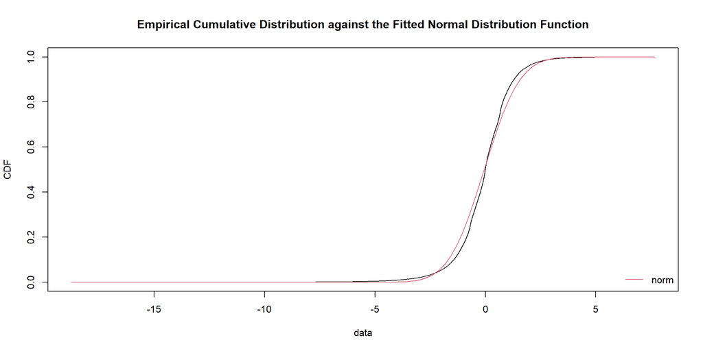

```r
# Fit the dataset to a normal distribution
fit_norm <- fitdist(as.vector(input_data_nna_ModZ), "norm", method = "mle", start=NULL, fix.arg=NULL, discrete = FALSE, keepdata = TRUE)

# Enable to make small versions of the four plots below
# plot(fit_norm)
#
# Enable to plot the Empirical Density against the Fitted Normal Distribution Function
# denscomp(fit_norm, probability = TRUE, main = "Empirical Density against the Fitted Normal Distribution Function", addlegend = TRUE, xlegend = "topright", ylegend = NULL, demp = TRUE, dempcol = "black", plotstyle = "graphics", fitnbpts = 101)
#
# Plot the Empirical Cumulative Distribution against the Fitted Normal Distribution Function
cdfcomp(fit_norm, xlogscale = FALSE, ylogscale = FALSE, main = "Empirical Cumulative Distribution against the Fitted Normal Distribution Function", datapch = 1, addlegend = TRUE, xlegend = "bottomright", ylegend = NULL, horizontals = TRUE, verticals = FALSE, do.points = TRUE, use.ppoints = TRUE, a.ppoints = 0.5, name.points = NULL, lines01 = FALSE, add = FALSE, plotstyle = "graphics", fitnbpts = 101)
```

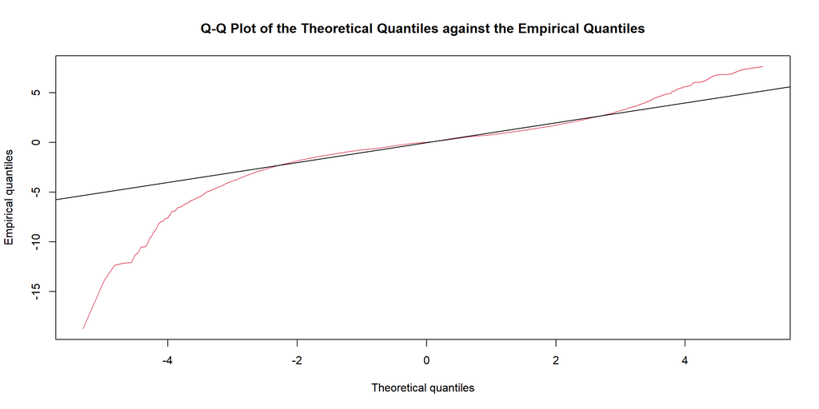

```r
# Q-Q Plot of the Theoretical Quantiles against the Empirical Quantiles
qqcomp(fit_norm, xlogscale = FALSE, ylogscale = FALSE, main = "Q-Q Plot of the Theoretical Quantiles against the Empirical Quantiles", addlegend = FALSE, xlegend = "bottomright", ylegend = NULL, use.ppoints = TRUE, a.ppoints = 0.5, line01 = TRUE, line01col = "black", line01lty = 1, ynoise = TRUE, plotstyle = "graphics")
```

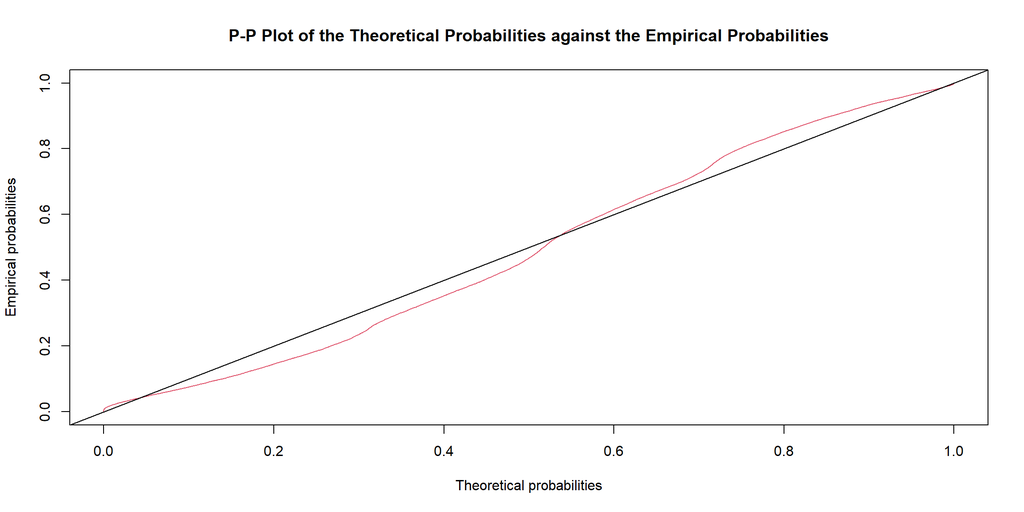

```r
# P-P Plot of the Theoretical Probabilities against the Empirical Probabilities
ppcomp(fit_norm, xlogscale = FALSE, ylogscale = FALSE, main = "P-P Plot of the Theoretical Probabilities against the Empirical Probabilities", addlegend = FALSE, xlegend = "bottomright", ylegend = NULL, use.ppoints = TRUE, a.ppoints = 0.5, line01 = TRUE, line01col = "black", line01lty = 1, ynoise = TRUE, plotstyle = "graphics")
```

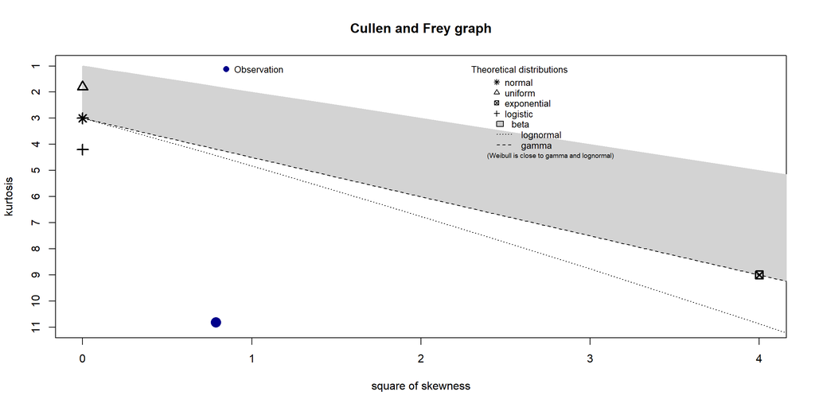

```
## summary statistics
## ------
## min:  -18.74971   max:  7.678407
## median:  0
## mean:  -0.05467876
## estimated sd:  1.270111
## estimated skewness:  -0.8872724
## estimated kurtosis:  10.80519
```

```r
# Plot the Cullen and Frey graph (skewness-kurtosis plot)
descdist(as.vector(input_data_nna_ModZ), discrete = FALSE)
```

```r
# Perform a Shapiro-Wilk normality test (max input values = 5000)
SW_input <- as.vector(input_data_nna_ModZ)
if (length(SW_input) > 5000) {
SW_input <- sample(SW_input, 5000, replace = FALSE, prob = NULL)
}
SW_output <- shapiro.test(SW_input)
SW_output$p.value
```

```
## [1] 3.727441e-45
```

```r
# Perform a Kolmogorov-Smirnov test to compare the dataset to a normal distribution
KS_output <- ks.test(as.vector(input_data_nna_ModZ), "pnorm", alternative = "two.sided")
KS_output$p.value
```

```
## [1] 0
```

## 2. Hierachical Clustering for the Cophenetic Correlation Coefficient

Hierarchical clustering analyses (HCAs) are performed, and the choice of the distance metric and linkage are determined using the Cophenetic Correlation Coefficient (CCC) (Selicato et al 2021). Three distance metrics and five linkages are used (15 HCA’s total). None of the three distance metrics are nonparametric so that the clustering is highly quantitative. The HCA that results in the largest CCC will be used for the downstream analyses. If this CCC < 0.8 (default value; CCC_min can be altered above), then the dendrogram is not a good representation of the relationships between the objects, and outliers can not be confidently detected (Selicato et al 2021). If CCC >= 0.8, the clustering was significant, and outliers can be detected if any exist.

```r
# Transpose the data so the sample will become the rows and genes/proteins will become the columns
input_data_nna_t <- t(input_data_nna)
rownames(input_data_nna_t)
```

```
##  [1] "ID_04_Female_EoE"       "ID_07_Female_EoE"       "ID_10_Female_EoE"
##  [4] "ID_12_Female_EoE"       "ID_biopsy_4_Female_EoE" "ID_01_Male_EoE"
##  [7] "ID_06_Male_EoE"         "ID_11_Male_EoE"         "ID_13_Male_EoE"
## [10] "ID_biopsy_2_Male_EoE"   "ID_03_Female_NL"        "ID_14_Female_NL"
## [13] "ID_15_Female_NL"        "ID_16_Female_NL"        "ID_biopsy_3_Female_NL"
## [16] "ID_02_Male_NL"          "ID_05_Male_NL"          "ID_08_Male_NL"
## [19] "ID_09_Male_NL"          "ID_biopsy_1_Male_NL"
```

```r
# Calculate distances: Euclidean, Manhattan, Pearson correlation coefficient
d_e <- dist(input_data_nna_t, method = "euclidean")
d_m <- dist(input_data_nna_t, method = "manhattan")
c_2 = cor(input_data_nna, method="pearson")
d_p <- as.dist(1 - c_2)

# Linkages: "average" (= UPGMA), "ward.D2", "complete", "single", "centroid" (= UPGMC)
# Hierarchical clustering using Euclidean distance
hc_e_a <- hclust(d_e, method = "average" )
hc_e_w <- hclust(d_e, method = "ward.D2" )
hc_e_co <- hclust(d_e, method = "complete" )
hc_e_s <- hclust(d_e, method = "single" )
hc_e_ce <- hclust(d_e, method = "centroid" )
# Hierarchical clustering using Manhattan distance
hc_m_a <- hclust(d_m, method = "average" )
hc_m_w <- hclust(d_m, method = "ward.D2" )
hc_m_co <- hclust(d_m, method = "complete" )
hc_m_s <- hclust(d_m, method = "single" )
hc_m_ce <- hclust(d_m, method = "centroid" )
# Hierarchical clustering using Pearson correlation coefficient
hc_p_a <- hclust(d_p, method = "average" )
hc_p_w <- hclust(d_p, method = "ward.D2" )
hc_p_co <- hclust(d_p, method = "complete" )
hc_p_s <- hclust(d_p, method = "single" )
hc_p_ce <- hclust(d_p, method = "centroid" )

# The Cophenetic Correlation Coefficient (CCC) is a measure of how faithfully a dendrogram preserves the pairwise distances between the original unmodeled data points.
res.coph_e_a <- cophenetic(hc_e_a)
res.coph_e_w <- cophenetic(hc_e_w)
res.coph_e_co <- cophenetic(hc_e_co)
res.coph_e_s <- cophenetic(hc_e_s)
res.coph_e_ce <- cophenetic(hc_e_ce)

res.coph_m_a <- cophenetic(hc_m_a)
res.coph_m_w <- cophenetic(hc_m_w)
res.coph_m_co <- cophenetic(hc_m_co)
res.coph_m_s <- cophenetic(hc_m_s)
res.coph_m_ce <- cophenetic(hc_m_ce)

res.coph_p_a <- cophenetic(hc_p_a)
res.coph_p_w <- cophenetic(hc_p_w)
res.coph_p_co <- cophenetic(hc_p_co)
res.coph_p_s <- cophenetic(hc_p_s)
res.coph_p_ce <- cophenetic(hc_p_ce)

# Correlations between the distance matrix and the Cophenetic Correlations
# are compared for 'euclidean', 'manhattan', and 'pearson' distances to see which
# one is the best.  The higher the correlation, the better the HCA.
# Create a dataframe to store the CCC values from each distance and linkage combination
distance = c("euclidean", "euclidean", "euclidean", "euclidean", "euclidean",
             'manhattan', 'manhattan', 'manhattan', 'manhattan', 'manhattan',
             'pearson', 'pearson', 'pearson', 'pearson', 'pearson')
linkage = c('average', 'ward.D2', 'complete', 'single', 'centroid',
            'average', 'ward.D2', 'complete', 'single', 'centroid',
            'average', 'ward.D2', 'complete', 'single', 'centroid')
distance_matrix = c('e_a', 'e_w', 'e_co', 'e_s', 'e_ce',
                    'm_a', 'm_w', 'm_co', 'm_s', 'm_ce',
                    'p_a', 'p_w', 'p_co', 'p_s', 'p_ce')
CCC = c(
  cor(d_e, res.coph_e_a),
  cor(d_e, res.coph_e_w),
  cor(d_e, res.coph_e_co),
  cor(d_e, res.coph_e_s),
  cor(d_e, res.coph_e_ce),

  cor(d_m, res.coph_m_a),
  cor(d_m, res.coph_m_w),
  cor(d_m, res.coph_m_co),
  cor(d_m, res.coph_m_s),
  cor(d_m, res.coph_m_ce),

  cor(d_p, res.coph_p_a),
  cor(d_p, res.coph_p_w),
  cor(d_p, res.coph_p_co),
  cor(d_p, res.coph_p_s),
  cor(d_p, res.coph_p_ce))

CCC_df = data.frame(distance, linkage, distance_matrix, CCC)
CCC_df_ranked = CCC_df[order(-CCC_df$CCC),]

# Display the CCC for each HCA
CCC_df_ranked
```

```
##     distance  linkage distance_matrix       CCC
## 1  euclidean  average             e_a 0.8924491
## 4  euclidean   single             e_s 0.8902876
## 6  manhattan  average             m_a 0.8794391
## 9  manhattan   single             m_s 0.8706242
## 15   pearson centroid            p_ce 0.8568624
## 5  euclidean centroid            e_ce 0.8451683
## 14   pearson   single             p_s 0.8362619
## 10 manhattan centroid            m_ce 0.8350737
## 11   pearson  average             p_a 0.8343426
## 3  euclidean complete            e_co 0.8295596
## 2  euclidean  ward.D2             e_w 0.8236982
## 13   pearson complete            p_co 0.8110106
## 8  manhattan complete            m_co 0.8024108
## 7  manhattan  ward.D2             m_w 0.7771904
## 12   pearson  ward.D2             p_w 0.7757789
```

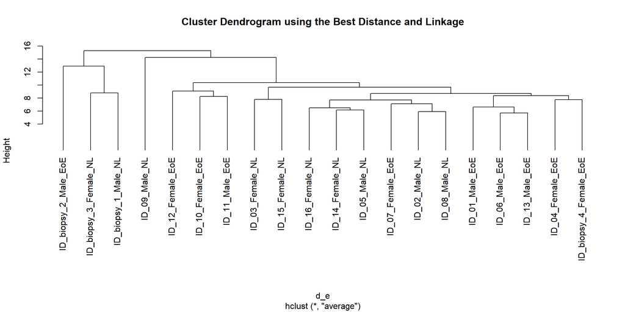

```r
# Find the best distance-linkage combination
CCC_df_ranked_top = CCC_df_ranked[1,]

# Get the hierarchical clustering object generated using the best distance-linkage
hc = get(paste0('hc_', CCC_df_ranked_top$distance_matrix))

# Display the dendrogram generated using the best distance-linkage
plot(hc, hang=-1, main='Cluster Dendrogram using the Best Distance and Linkage')
```

## 3. Hierachical Clustering for the Silhouette Coefficients

The Silhouette coefficient (SC) is calculated for each sample. A sample with SC < 0.25 (default value; SC_max can be altered above) is a potential outlier because it clustered poorly with the other samples; a sample with SC >= 0.25 is not a potential outlier (Selicato et al 2021).

```r
# Calculate the maximum possible number of clusters
# Note that eclust() -> hcut() might crash if this value is > 20
# Note that eclust() -> hcut() might crash if this value is > (input_data_col - 1)
MaxPosNumClusters <- min(c(20 , (input_data_col - 1) ))
MaxPosNumClusters
```

```
## [1] 19
```

```r
# eclust() - Visual enhancement of clustering analysis for enhancing the
# workflow of clustering analyses and ggplot2-based data visualization
hc.res_a <- eclust(input_data_nna_t, FUNcluster = "hclust", k = NULL, k.max = MaxPosNumClusters, stand = FALSE, graph = FALSE, hc_metric = CCC_df_ranked_top$distance, hc_method = CCC_df_ranked_top$linkage, nboot=100, seed=78)

# Display the estimated optimal number of clusters from eclust() gap statistics
nbclust_GapStat <- hc.res_a$nbclust
nbclust_GapStat
```

```
## [1] 1
```

```r
# If the estimated optimal number of clusters = 1, then the eclust() gap statistic
# method failed to identify an optimal number of clusters.
# Use the silhouette method (max of mean of SC values) (Charrad et al 2014).
if (nbclust_GapStat == 1) {

# Make a data frame for the mean SC at each possible number of clusters
numClust_i <- 1:MaxPosNumClusters
numClust_AvgSC <- rep(0.001, MaxPosNumClusters)
numClust_df <- data.frame(numClust_i, numClust_AvgSC)

# Loop through each possible number of clusters and save the mean SC
for (i in 2:MaxPosNumClusters) {

    hc.res_a <- eclust(input_data_nna_t, FUNcluster = "hclust", k = i, stand = FALSE, graph = FALSE, hc_metric = CCC_df_ranked_top$distance, hc_method = CCC_df_ranked_top$linkage, nboot=100, seed=78)

    # Silhouette information
    silinfo_a <- hc.res_a$silinfo
    numClust_df[i, 2] <- silinfo_a$avg.width

    }

# Sort rows by the mean SC (descending)
numClust_df_ranked <- numClust_df[order(-numClust_df$numClust_AvgSC),]

# Find the estimated optimal number of clusters
numClust_df_ranked_top <- numClust_df_ranked[1,]

# Perform an HCA and calculate SC values using the estimated optimal number of clusters
hc.res_a <- eclust(input_data_nna_t, FUNcluster = "hclust", k = numClust_df_ranked_top[1], stand = FALSE, graph = FALSE, hc_metric = CCC_df_ranked_top$distance, hc_method = CCC_df_ranked_top$linkage, nboot=100, seed=78)

}

# Display the mean SC at each number of clusters (if silhouette method was used)
if (nbclust_GapStat == 1) {
  numClust_df_ranked
}
```

```
##    numClust_i numClust_AvgSC
## 2           2     0.34458585
## 3           3     0.29696118
## 4           4     0.27803657
## 5           5     0.16406537
## 6           6     0.13894770
## 7           7     0.11834896
## 10         10     0.09564590
## 9           9     0.09355731
## 8           8     0.08770191
## 11         11     0.08666877
## 12         12     0.07041820
## 14         14     0.06851202
## 15         15     0.06099749
## 13         13     0.05914035
## 16         16     0.04239724
## 17         17     0.02717025
## 18         18     0.02353119
## 19         19     0.01390384
## 1           1     0.00100000
```

```r
# Display the final estimated optimal number of clusters
hc.res_a$nbclust
```

```
##   numClust_i
## 2          2
```

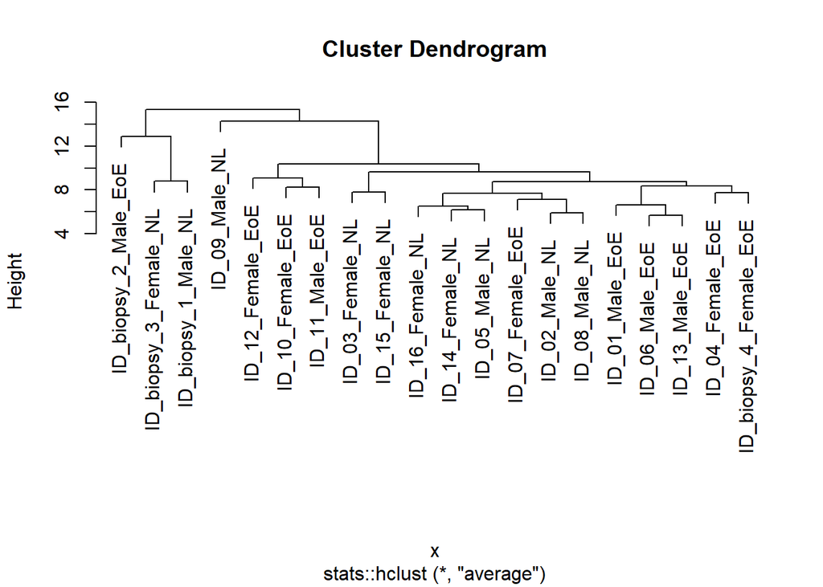

```r
# Display the dendrogram
plot(hc.res_a)
```

```
##   cluster size ave.sil.width
## 1       1   17          0.36
## 2       2    3          0.25
```

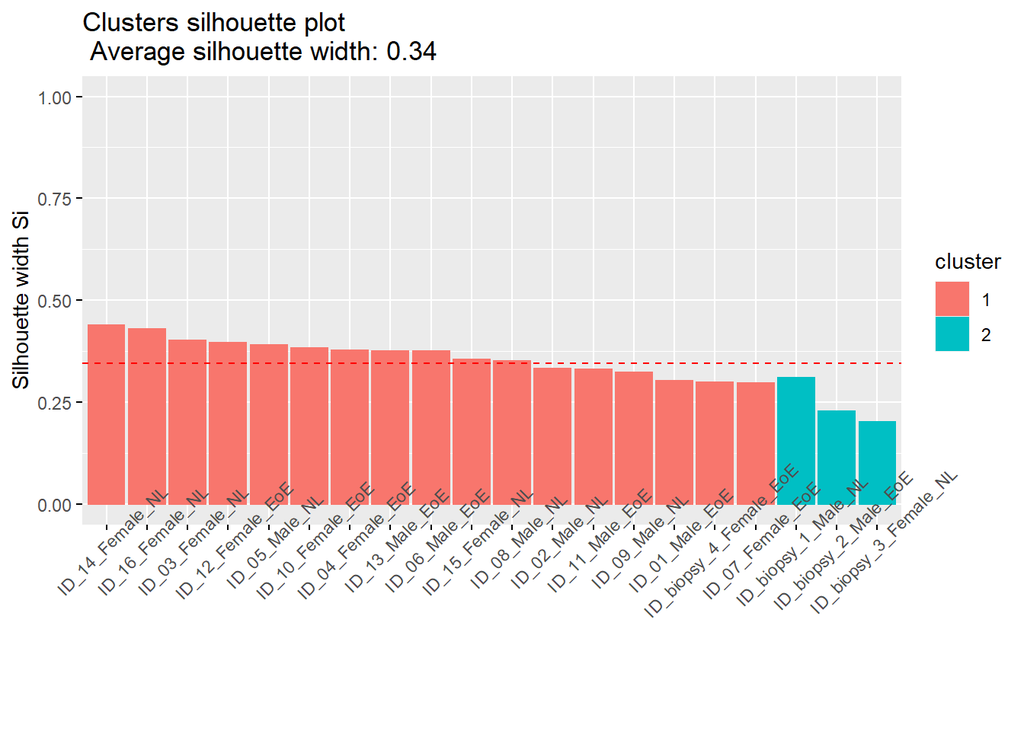

```r
# Visualize Silhouette coefficients
if (input_data_col <= 50) {
  fviz_silhouette(hc.res_a, label = TRUE)
} else {
  fviz_silhouette(hc.res_a, label = FALSE)
}
```

```r
# Silhouette information
silinfo_a <- hc.res_a$silinfo

# The Silhouette coefficient of each sample
sil_a <- hc.res_a$silinfo$widths[, 1:3]
sil_a
```

```
##                        cluster neighbor sil_width
## ID_14_Female_NL              1        2 0.4382383
## ID_16_Female_NL              1        2 0.4292472
## ID_03_Female_NL              1        2 0.4010306
## ID_12_Female_EoE             1        2 0.3947868
## ID_05_Male_NL                1        2 0.3904959
## ID_10_Female_EoE             1        2 0.3833563
## ID_04_Female_EoE             1        2 0.3766638
## ID_13_Male_EoE               1        2 0.3759949
## ID_06_Male_EoE               1        2 0.3756722
## ID_15_Female_NL              1        2 0.3552708
## ID_08_Male_NL                1        2 0.3509446
## ID_02_Male_NL                1        2 0.3325174
## ID_11_Male_EoE               1        2 0.3300177
## ID_09_Male_NL                1        2 0.3221768
## ID_01_Male_EoE               1        2 0.3031540
## ID_biopsy_4_Female_EoE       1        2 0.2985879
## ID_07_Female_EoE             1        2 0.2963081
## ID_biopsy_1_Male_NL          2        1 0.3100421
## ID_biopsy_2_Male_EoE         2        1 0.2267253
## ID_biopsy_3_Female_NL        2        1 0.2004862
```

```r
# The average silhouette coefficient of each cluster
silinfo_a$clus.avg.widths
```

```
## [1] 0.3620273 0.2457512
```

```r
# The average silhouette coefficient
silinfo_a$avg.width
```

```
## [1] 0.3445858
```

```r
# The size of each cluster
hc.res_a$size
```

```
## [1] 17  3
```

```r
# Identify the potential outliers
neg_sil_index_a <- which(sil_a[, 'sil_width'] < SC_max)

# Get the potential outlier sample names
hcOutliers = rownames(sil_a[neg_sil_index_a, , drop = FALSE])
hcOutliers
```

```
## [1] "ID_biopsy_2_Male_EoE"  "ID_biopsy_3_Female_NL"
```

## 4. Robust PCA

Robust PCA is used to detect outliers (Hubert et al 2005). The samples are plotted on a diagnostic plot (diagPlot), aka, a Distance-Distance plot (DD-plot; not to be confused with a plot of PC1 vs. PC2). There are two cutoffs (one horizontal, one vertical) used to classify each sample as an outlier or a non-outlier. Each cutoff corresponds to a 97.5% probability (default setting) that a sample from a normal distribution would not be falsely classified as an outlier. The two cutoffs, robpca_prob and PcaGrid_prob, can be altered at the beginning of the script. If the sample is in the lower-left section of the DD-plot, it is classified as a non-outlier; otherwise, it is classified as an outlier.

### 4.1 Robust Sparse PCA algorithm (robpca)

The sparse robust PCA algorithm (robpca) is based on the ROBPCA algorithm (Hubert et al 2005). rospca has been used to detect outliers in transcriptomics datasets (Selicato et al 2021).

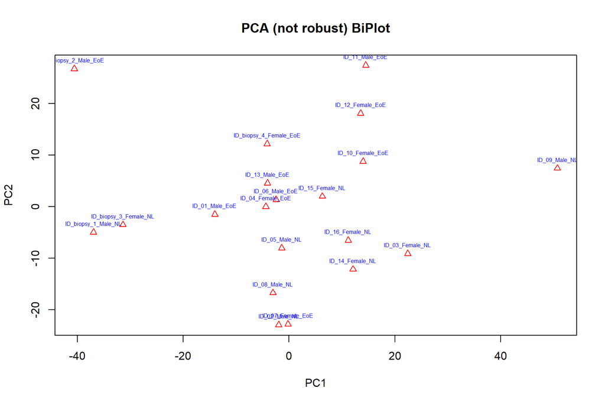

```r
library(rospca)

# Perform a PCA (not robust)
PCA_classic <- prcomp(input_data_nna_t, retx = TRUE, center = TRUE, scale. = TRUE, tol = NULL, rank. = NULL)

# Plot the non-robust PCA results on a PC1-vs-PC2 biplot.  Use text() to include labels.
if (input_data_col <= 50) {
  plot(PCA_classic$x, pch=2, col="red", main = "PCA (not robust) BiPlot")
  text(PCA_classic$x, labels=rownames(PCA_classic$x), cex=0.5, pos=3, col="blue")
} else {
  plot(PCA_classic$x, pch=2, col="red", main = "PCA (not robust) BiPlot")
}
```

```r
# Display table of the non-robust PCA results
PCA_classic$x[,c(1,2)]
```

```
##                                PC1          PC2
## ID_04_Female_EoE        -4.3966146   0.00706496
## ID_07_Female_EoE        -0.1983835 -22.79904159
## ID_10_Female_EoE        13.9713821   8.74423651
## ID_12_Female_EoE        13.5099561  18.05385370
## ID_biopsy_4_Female_EoE  -4.1463401  12.14122934
## ID_01_Male_EoE         -14.0290993  -1.52470409
## ID_06_Male_EoE          -2.4497950   1.33661902
## ID_11_Male_EoE          14.4788724  27.36074988
## ID_13_Male_EoE          -4.0843850   4.55382358
## ID_biopsy_2_Male_EoE   -40.5688838  26.67724857
## ID_03_Female_NL         22.4333732  -9.09634653
## ID_14_Female_NL         12.0949659 -12.15333191
## ID_15_Female_NL          6.2790516   1.98634557
## ID_16_Female_NL         11.1783812  -6.55193100
## ID_biopsy_3_Female_NL  -31.4089227  -3.51984654
## ID_02_Male_NL           -1.9621710 -22.90456477
## ID_05_Male_NL           -1.3965474  -8.04353555
## ID_08_Male_NL           -3.0390321 -16.69672512
## ID_09_Male_NL           50.6948620   7.42103099
## ID_biopsy_1_Male_NL    -36.9606700  -4.99217501
```

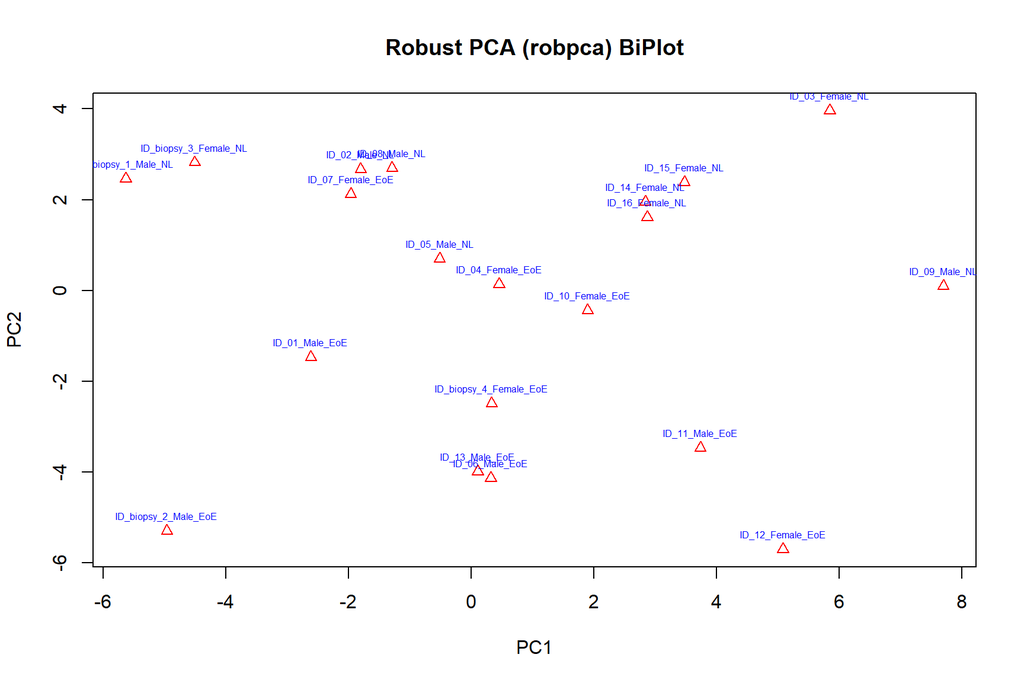

```r
# Perform Robust PCA (robpca)
resR0 <- robpca(input_data_nna_t, k = 0, crit.pca.distances = robpca_prob, ndir = 5000, skew = FALSE)

# Plot the robpca results on a PC1-vs-PC2 biplot.  Use text() to include labels.
if (input_data_col <= 50) {
  plot(resR0$scores, pch=2, col="red", main = "Robust PCA (robpca) BiPlot")
  text(resR0$scores, labels=rownames(resR0$scores), cex=0.5, pos=3, col="blue")
  } else {
  plot(resR0$scores, pch=2, col="red", main = "Robust PCA (robpca) BiPlot")
  }
```

```r
# Display table of the robpca results
resR0$scores[,c(1,2)]
```

```
##                               PC1         PC2
## ID_04_Female_EoE        0.4578932  0.13152059
## ID_07_Female_EoE       -1.9611576  2.12167069
## ID_10_Female_EoE        1.9005204 -0.44318486
## ID_12_Female_EoE        5.0864609 -5.69535097
## ID_biopsy_4_Female_EoE  0.3370910 -2.49177319
## ID_01_Male_EoE         -2.6113846 -1.46938044
## ID_06_Male_EoE          0.3221783 -4.13294137
## ID_11_Male_EoE          3.7388173 -3.46879256
## ID_13_Male_EoE          0.1115822 -3.98523646
## ID_biopsy_2_Male_EoE   -4.9591680 -5.29181422
## ID_03_Female_NL         5.8483844  3.95779486
## ID_14_Female_NL         2.8422676  1.95272622
## ID_15_Female_NL         3.4786991  2.38047377
## ID_16_Female_NL         2.8754650  1.61612328
## ID_biopsy_3_Female_NL  -4.5051548  2.81749470
## ID_02_Male_NL          -1.7989271  2.67296057
## ID_05_Male_NL          -0.5113656  0.69991900
## ID_08_Male_NL          -1.2858793  2.69834753
## ID_09_Male_NL           7.7018329  0.09591435
## ID_biopsy_1_Male_NL    -5.6275053  2.46065029
```

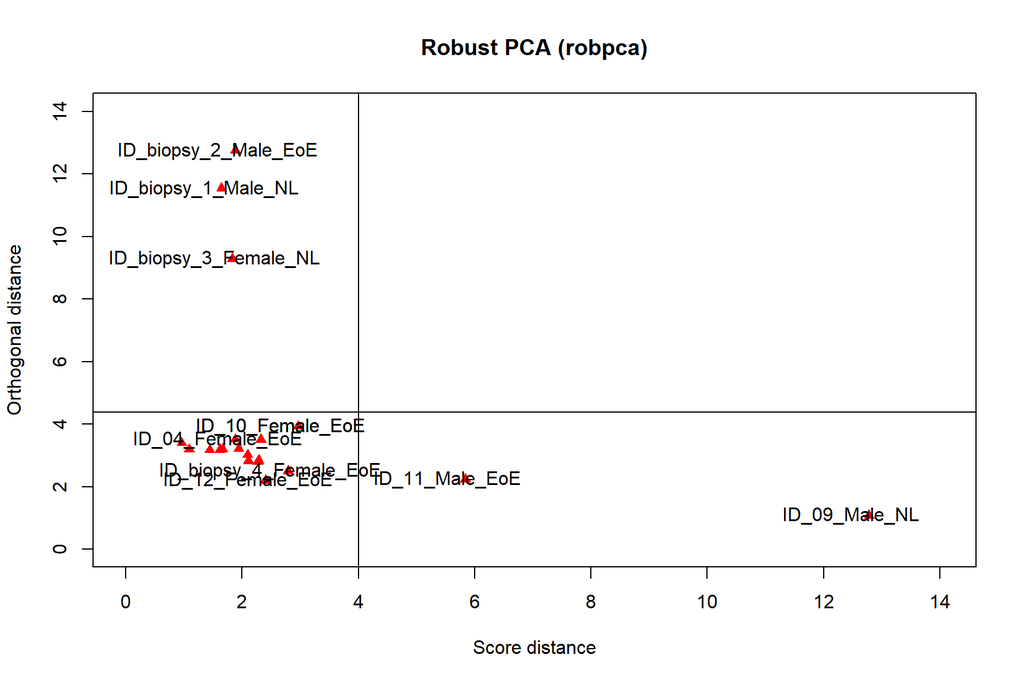

```r
# Diagnositc plot (DD-plot or outlier map)
diagPlot(resR0, title = "Robust PCA (robpca)", pch = 17, col="red", labelOut = TRUE, id = 5)
```

```r
# Display the robpca results (outliers are 'FALSE')
resR0_flag <- as.data.frame(resR0$flag.all)
resR0_flag
```

```
##                        resR0$flag.all
## ID_04_Female_EoE                 TRUE
## ID_07_Female_EoE                 TRUE
## ID_10_Female_EoE                 TRUE
## ID_12_Female_EoE                 TRUE
## ID_biopsy_4_Female_EoE           TRUE
## ID_01_Male_EoE                   TRUE
## ID_06_Male_EoE                   TRUE
## ID_11_Male_EoE                  FALSE
## ID_13_Male_EoE                   TRUE
## ID_biopsy_2_Male_EoE            FALSE
## ID_03_Female_NL                  TRUE
## ID_14_Female_NL                  TRUE
## ID_15_Female_NL                  TRUE
## ID_16_Female_NL                  TRUE
## ID_biopsy_3_Female_NL           FALSE
## ID_02_Male_NL                    TRUE
## ID_05_Male_NL                    TRUE
## ID_08_Male_NL                    TRUE
## ID_09_Male_NL                   FALSE
## ID_biopsy_1_Male_NL             FALSE
```

```r
resR0_flag$sample <- row.names(resR0_flag)
colnames(resR0_flag) <- c('regular', 'sample')
resR0_flag$regular <- as.numeric(resR0_flag$regular)

# Display the outlier sample names
rosOutliers = resR0_flag[resR0_flag$regular == 0,]$sample
rosOutliers
```

```
## [1] "ID_11_Male_EoE"        "ID_biopsy_2_Male_EoE"  "ID_biopsy_3_Female_NL"
## [4] "ID_09_Male_NL"         "ID_biopsy_1_Male_NL"
```

### 4.2 Robust PCA based on Projection Pursuit (PP) using GRID (PcaGrid)

PcaGrid computes an approximation of the PP-estimators for a robust PCA using the GRID algorithm to detect outlier samples. It was compared with PcaHubert, and had better sensitivity and specificity for simulated and real transcriptomics data (Chen et al 2020).

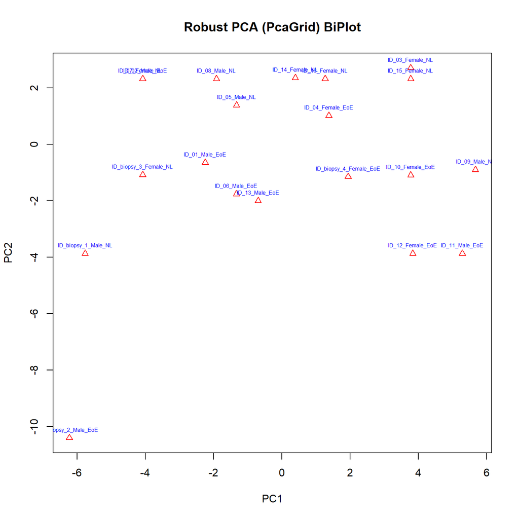

```r
library(rrcov)

# Perform a Robust PCA (PcaGrid)
pc <- PcaGrid(input_data_nna_t, crit.pca.distances = PcaGrid_prob)

# Plot the PcaGrid results on a PC1-vs-PC2 biplot.  Use text() to include labels.
if (input_data_col <= 50) {
  plot(pc$scores, pch=2, col="red", main = "Robust PCA (PcaGrid) BiPlot")
  text(pc$scores, labels=rownames(pc$scores), cex=0.5, pos=3, col="blue")
  } else {
  plot(pc$scores, pch=2, col="red", main = "Robust PCA (PcaGrid) BiPlot")
  }
```

```r
# Display table of the PcaGrid results
pc$scores[,c(1,2)]
```

```
##                               PC1         PC2
## ID_04_Female_EoE        1.3715297   1.0106839
## ID_07_Female_EoE       -4.0804781   2.3194399
## ID_10_Female_EoE        3.7712610  -1.0910097
## ID_12_Female_EoE        3.8298736  -3.8734183
## ID_biopsy_4_Female_EoE  1.9368595  -1.1472270
## ID_01_Male_EoE         -2.2513907  -0.6533427
## ID_06_Male_EoE         -1.3351863  -1.7652499
## ID_11_Male_EoE          5.2810700  -3.8744810
## ID_13_Male_EoE         -0.7000955  -2.0006618
## ID_biopsy_2_Male_EoE   -6.2295794 -10.4070292
## ID_03_Female_NL         3.7712600   2.7108301
## ID_14_Female_NL         0.3907908   2.3587960
## ID_15_Female_NL         3.7717962   2.3194916
## ID_16_Female_NL         1.2631739   2.3233534
## ID_biopsy_3_Female_NL  -4.0805470  -1.0792107
## ID_02_Male_NL          -4.0806091   2.3195971
## ID_05_Male_NL          -1.3342078   1.3861954
## ID_08_Male_NL          -1.9215823   2.3226679
## ID_09_Male_NL           5.6669830  -0.9005980
## ID_biopsy_1_Male_NL    -5.7685417  -3.8741977
```

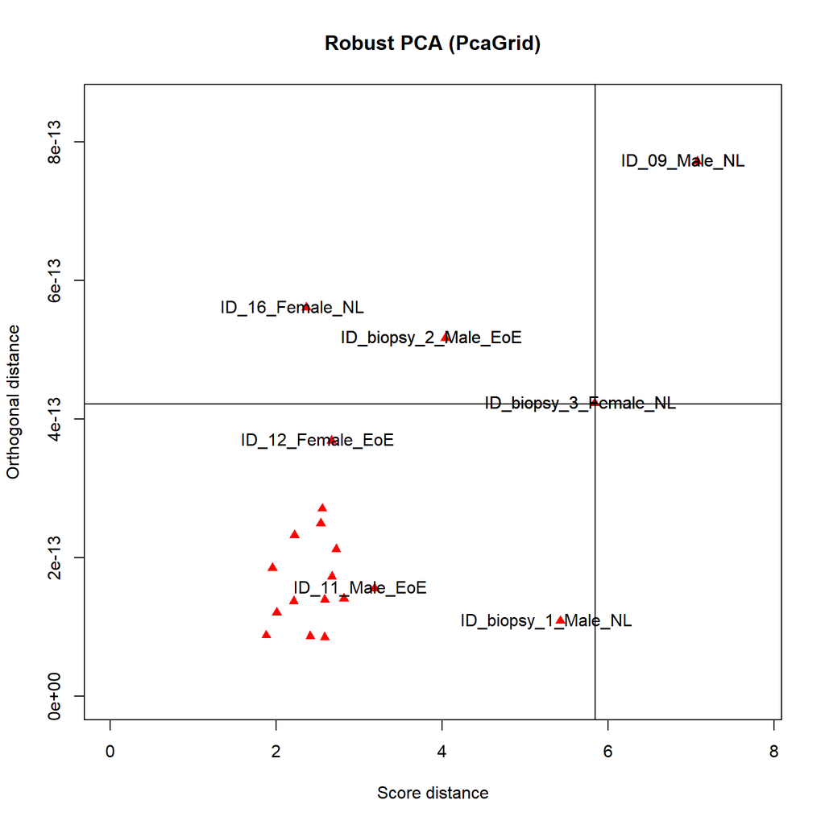

```r
# Diagnositc plot (DD-plot or outlier map)
diagPlot(pc, title = "Robust PCA (PcaGrid)", pch = 17, col="red", labelOut = TRUE, id = 5)
```

```r
# Display the results (outliers = FALSE)
pc_flag <- as.data.frame(pc$flag)
pc_flag
```

```
##                        pc$flag
## ID_04_Female_EoE          TRUE
## ID_07_Female_EoE          TRUE
## ID_10_Female_EoE          TRUE
## ID_12_Female_EoE          TRUE
## ID_biopsy_4_Female_EoE    TRUE
## ID_01_Male_EoE            TRUE
## ID_06_Male_EoE            TRUE
## ID_11_Male_EoE            TRUE
## ID_13_Male_EoE            TRUE
## ID_biopsy_2_Male_EoE     FALSE
## ID_03_Female_NL           TRUE
## ID_14_Female_NL           TRUE
## ID_15_Female_NL           TRUE
## ID_16_Female_NL          FALSE
## ID_biopsy_3_Female_NL    FALSE
## ID_02_Male_NL             TRUE
## ID_05_Male_NL             TRUE
## ID_08_Male_NL             TRUE
## ID_09_Male_NL            FALSE
## ID_biopsy_1_Male_NL       TRUE
```

```r
pc_flag$sample <- row.names(pc_flag)
colnames(pc_flag) <- c('regular', 'sample')
pc_flag$regular <- as.numeric(pc_flag$regular)

# Display the outlier sample names
pcOutliers = pc_flag[pc_flag$regular == 0,]$sample
pcOutliers
```

```
## [1] "ID_biopsy_2_Male_EoE"  "ID_16_Female_NL"       "ID_biopsy_3_Female_NL"
## [4] "ID_09_Male_NL"
```

## 5. Summary of the Results and Identification of Outlier(s)

In this analysis, three different methods were used to examine the samples. They complement each other in the identification of potential outlier(s). First, the density plot (made using “plotDensities”) was used to visualize how similar the expression patterns were across the samples. Second, hierarchical clustering was used to examine how close the samples are to each other; closely related samples formed a tight cluster. The Cophenetic Correlation Coefficient (CCC) was used to evaluate if the dendrogram is a good representation of the similarity among the samples. The Silhouette coefficient (SC) was used to examine how strongly each sample belonged to its cluster. Finally, robust PCA analyses were performed using two different algorithms, robpca and PcaGrid. These were used to identify outlier(s) that surpassed a probability threshold. The PcaGrid test was described by Chen et al 2020, and the CCC, SC, and robpca tests were described by Selicato et al 2021.

The robust PCA analyses use statistical testing to robustly identify the outlier(s). The density plot and hierarchical clustering provide additional visual and descriptive information. Ideally, they will confirm the rPCA results by showing that the outlier(s) are distant from the other samples.

### 5.1 Outlier(s) Identified by Robust PCA analyses

```r
# A robpca cutoff of 0.975 is recommended (Selicato et al 2021).
# At the start of the script, the robpca cutoff was set to:
robpca_prob
```

```
## [1] 0.975
```

```r
# The samples that are outside this cutoff are potential outliers, and the other samples are not.
# The samples that are outside this cutoff:
rosOutliers
```

```
## [1] "ID_11_Male_EoE"        "ID_biopsy_2_Male_EoE"  "ID_biopsy_3_Female_NL"
## [4] "ID_09_Male_NL"         "ID_biopsy_1_Male_NL"
```

```r
# A PcaGrid cutoff of 0.975 is recommended (Chen et al 2020).
# At the start of the script, the PcaGrid cutoff was set to:
PcaGrid_prob
```

```
## [1] 0.975
```

```r
# The samples that are outside this cutoff are potential outliers, and the other samples are not.
# The samples that are outside this cutoff:
pcOutliers
```

```
## [1] "ID_biopsy_2_Male_EoE"  "ID_16_Female_NL"       "ID_biopsy_3_Female_NL"
## [4] "ID_09_Male_NL"
```

```r
# The samples that satisfied both robust PCA (robpca and PcaGrid) criteria for an outlier:
intersect(pcOutliers, rosOutliers)
```

```
## [1] "ID_biopsy_2_Male_EoE"  "ID_biopsy_3_Female_NL" "ID_09_Male_NL"
```

### 5.2 Outlier(s) Identified by Hiearchical Clustering

```r
# A CCC cutoff of 0.8 is recommended (Selicato et al 2021).
# At the start of the script, the CCC cutoff was set to:
CCC_min
```

```
## [1] 0.8
```

```r
# The CCC was calculated:
CCC_df_ranked_top$CCC
```

```
## [1] 0.8924491
```

```r
# Did the input data pass the CCC test? (TRUE = yes, FALSE = no)
# If TRUE, then the HCA clustering was informative, and subsequent outlier detection can be informative.
# If FALSE, then the HCA clustering wasn't informative, and subsequent outlier detection won't be informative.
CCC_df_ranked_top$CCC >= CCC_min
```

```
## [1] TRUE
```

```r
# An SC cutoff of 0.25 is recommended (Selicato et al 2021).
# At the start of the script, the SC cutoff was set to:
SC_max
```

```
## [1] 0.25
```

```r
# The samples that have an SC value lower than the SC cutoff
# are potential outliers, and the other samples are not.
# The samples that have an SC value lower than the SC cutoff:
hcOutliers
```

```
## [1] "ID_biopsy_2_Male_EoE"  "ID_biopsy_3_Female_NL"
```

```r
# The samples that satisfied the CCC, SC, and robpca criteria for an outlier:
if (CCC_df_ranked_top$CCC >= CCC_min) {
  intersect(hcOutliers, rosOutliers)
}
```

```
## [1] "ID_biopsy_2_Male_EoE"  "ID_biopsy_3_Female_NL"
```

### 5.3 Outlier(s) Identified by Both HCA and Robust PCA

```r
# The samples that satisfied all four criteria (CCC, SC, robpca, PcaGrid) for an outlier:
if (CCC_df_ranked_top$CCC >= CCC_min) {
  intersect(intersect(hcOutliers, rosOutliers), pcOutliers)
}
```

```
## [1] "ID_biopsy_2_Male_EoE"  "ID_biopsy_3_Female_NL"
```

## 6. References

Boris Iglewicz and David Hoaglin 1993 “Volume 16: How to Detect and Handle Outliers”, The ASQC Basic References in Quality Control: Statistical Techniques, Edward F. Mykytka, Ph.D., Editor.

Charrad et al 2014 NbClust: An R Package for Determining the Relevant Number of Clusters in a Data Set. J Statistical Software 61:1-36.

Chen et al 2020 Robust principal component analysis for accurate outlier sample detection in RNA-Seq data. BMC Bioinformatics. 21:269.

Hubert et al 2005 ROBPCA: a new approach to robust prinicipal component analysis. Technometrics 47(1):64-79.

Selicato et al 2021 A New Ensemble Method for Detecting Anomalies in Gene Expression Matrices. Mathematics 9:882.

Spiess and Neumeyer 2010 An evaluation of R2 as an inadequate measure for nonlinear models in pharmacological and biochemical research: a Monte Carlo approach. BMC Pharmacol 10:6.